# Econometric Time-Series Forecasting of Zinc Prices (1990-2025): ARIMA Modeling and Statistical Diagnostics

## 4. Extrapolative Model and Benchmark

To provide a benchmark comparison for the ARIMA results, an extrapolative model from the Holt linear exponential smoothing family was also estimated.

The Holt model was trained using the same data split as the ARIMA models, with the final 12 months reserved as the test sample. The model parameters were determined using automatic optimization procedures.

This comparison indicates that ARIMA models provide a more accurate representation of the stochastic dynamics of zinc prices. While the Holt model captures general trends effectively, it is less capable of representing the complex cyclical behavior observed in commodity price series.

The results therefore confirm that ARIMA models are more suitable for short-term forecasting of zinc prices in the analyzed dataset.

```r
auto_fit <- forecast::auto.arima(train_log, seasonal = FALSE)
auto_fc <- forecast::forecast(auto_fit, h = h)

holt_fit <- forecast::holt(train_log, h = h, damped = TRUE, initial = "optimal")

benchmark_log <- dplyr::bind_rows(
  calc_metrics(test_log_vec, as.numeric(best_holdout_fc$mean)) %>% dplyr::mutate(model = best_model_name),
  calc_metrics(test_log_vec, as.numeric(auto_fc$mean)) %>% dplyr::mutate(model = "auto.arima"),
  calc_metrics(test_log_vec, as.numeric(holt_fit$mean)) %>% dplyr::mutate(model = "Holt (damped)")
) %>%
  dplyr::select(model, MAE, MSE, RMSE, MAPE, AMAPE) %>%
  dplyr::arrange(RMSE)

benchmark_level <- dplyr::bind_rows(
  calc_metrics(actual_level, exp(as.numeric(best_holdout_fc$mean))) %>% dplyr::mutate(model = best_model_name),
  calc_metrics(actual_level, exp(as.numeric(auto_fc$mean))) %>% dplyr::mutate(model = "auto.arima"),
  calc_metrics(actual_level, exp(as.numeric(holt_fit$mean))) %>% dplyr::mutate(model = "Holt (damped)")
) %>%
  dplyr::select(model, MAE, MSE, RMSE, MAPE, AMAPE) %>%
  dplyr::arrange(RMSE)

knitr::kable(benchmark_log, digits = 4, caption = "Table 9A. Benchmark comparison (log scale)")
```

Table 9A. Benchmark comparison (log scale)

| model | MAE | MSE | RMSE | MAPE | AMAPE |
| --- | --- | --- | --- | --- | --- |
| auto.arima | 0.1425 | 0.0220 | 0.1482 | 1.7872 | 1.8046 |
| ARIMA(1,1,1) | 0.1427 | 0.0220 | 0.1484 | 1.7897 | 1.8072 |
| Holt (damped) | 0.1554 | 0.0258 | 0.1607 | 1.9491 | 1.9695 |

```r
knitr::kable(benchmark_level, digits = 4, caption = "Table 9B. Benchmark comparison (USD levels)")
```

Table 9B. Benchmark comparison (USD levels)

| model | MAE | MSE | RMSE | MAPE | AMAPE |
| --- | --- | --- | --- | --- | --- |
| auto.arima | 383.8763 | 161294.5 | 401.6148 | 13.2116 | 14.2214 |
| ARIMA(1,1,1) | 384.3707 | 161678.2 | 402.0922 | 13.2288 | 14.2412 |
| Holt (damped) | 415.7661 | 186914.5 | 432.3361 | 14.3222 | 15.5025 |

*Source: Author’s own elaboration*

```r
holt_fitted_log <- extract_first_column(holt_fit$fitted)

train_level_actual <- exp(train_log_vec)
train_level_fitted <- exp(holt_fitted_log)
fit_idx <- which(!is.na(train_level_actual) & !is.na(train_level_fitted))

holt_train_metrics <- calc_metrics(train_level_actual[fit_idx], train_level_fitted[fit_idx])
holt_test_metrics <- calc_metrics(actual_level, exp(as.numeric(holt_fit$mean)))

table_11 <- tibble::tibble(
  Metric = c("MAE", "MSE", "MAPE", "AMAPE"),
  `Fit (train)` = c(
    holt_train_metrics$MAE,
    holt_train_metrics$MSE,
    holt_train_metrics$MAPE,
    holt_train_metrics$AMAPE
  ),
  `Forecast error (test)` = c(
    holt_test_metrics$MAE,
    holt_test_metrics$MSE,
    holt_test_metrics$MAPE,
    holt_test_metrics$AMAPE
  )
)

knitr::kable(
  table_11,
  digits = 4,
  caption = "Table 11. Fit and forecast errors for the Holt model"
)
```

Table 11. Fit and forecast errors for the Holt model

| Metric | Fit (train) | Forecast error (test) |
| --- | --- | --- |
| MAE | 89.7229 | 415.7661 |
| MSE | 20072.1058 | 186914.4966 |
| MAPE | 4.5311 | 14.3222 |
| AMAPE | 4.4965 | 15.5025 |

*Source: Author’s own elaboration*

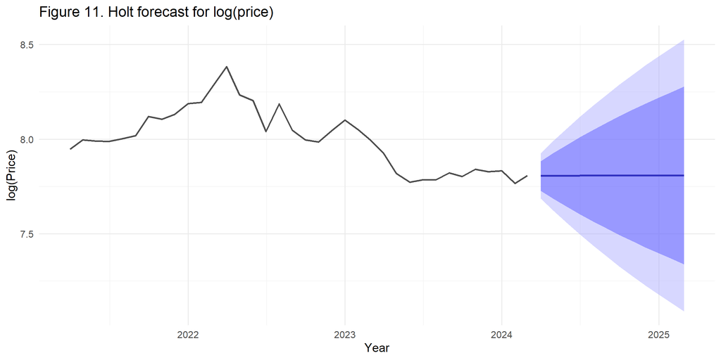

```r
holt_future <- forecast::forecast(holt_fit, h = h, level = c(80, 95))

train_dates <- zinc_df$date[1:(n - h)]
history_tail <- tibble::tibble(
  date = tail(train_dates, min(36, length(train_dates))),
  value = tail(train_log_vec, min(36, length(train_log_vec)))
)

holt_fc_df <- tibble::tibble(
  date = test_dates,
  point = as.numeric(holt_future$mean),
  lo80 = as.numeric(holt_future$lower[, "80%"]),
  hi80 = as.numeric(holt_future$upper[, "80%"]),
  lo95 = as.numeric(holt_future$lower[, "95%"]),
  hi95 = as.numeric(holt_future$upper[, "95%"])
)

ggplot2::ggplot() +
  ggplot2::geom_line(
    data = history_tail,
    ggplot2::aes(x = date, y = value),
    color = "#4d4d4d",
    linewidth = 0.8
  ) +
  ggplot2::geom_ribbon(
    data = holt_fc_df,
    ggplot2::aes(x = date, ymin = lo95, ymax = hi95),
    fill = "#a6a6ff",
    alpha = 0.45
  ) +
  ggplot2::geom_ribbon(
    data = holt_fc_df,
    ggplot2::aes(x = date, ymin = lo80, ymax = hi80),
    fill = "#4d4dff",
    alpha = 0.45
  ) +
  ggplot2::geom_line(
    data = holt_fc_df,
    ggplot2::aes(x = date, y = point),
    color = "#3030c0",
    linewidth = 0.9
  ) +
  ggplot2::labs(
    title = "Figure 11. Holt forecast for log(price)",
    x = "Year",
    y = "log(Price)"
  ) +
  ggplot2::theme_minimal(base_size = 12)
```

*Source: Author’s own elaboration*

## Conclusions

- Box-Cox and stationarity diagnostics are explicitly documented with both profile plot and table outputs.
- Breusch-Godfrey and Ljung-Box diagnostics are included in full report form.
- ARIMA candidate set is evaluated through coefficients, information criteria, residual tests, and holdout errors.
- Extrapolative Holt benchmark includes both fit/forecast error tables and forecast visualization.

## RPubs Publishing

1. Knit this report to HTML.
2. In RStudio, click **Publish** and choose **RPubs**.
3. Add metadata and publish.
4. Share the RPubs URL as the chapter deliverable.